# Demo of `bouldr`: a ROC Extender Package

Josh Langfus & Sandra Williams

4/21/2020

git repo: https://github.com/jlangaa/PSYC859.SP20.git

# Setup

First, we’ll source three scripts. These scripts contain the functions we’re going to use:

- `gen_gest_data.R` generates test data of the appropriate dimensions and types.
- `bouldr.R` contains the main roc-hunting logic, built on `pROC`
- `rocplot.R` contains functions for plotting

```r
set.seed(2020)
source('gen_test_data.R')
source('bouldr.R')
source('rocplot.R')
options(digits = 2)
# source("module 1.R")
# source("module 2.R")
```

Next, we’ll generage some test data.

```r
dd <- gen.test.data(10,Diagnosis = c("Depression","Anxiety","ADHD"),
                          Measure = c("A","B"),
                          Informant = c("Self","Parent", "Teacher"))
```

```r
head(dd)
```

| ID | Diagnosis | Measure | Informant | Outcome | Score |
| --- | --- | --- | --- | --- | --- |
| 1 | Depression | A | Self | no | 0.78 |
| 2 | Depression | A | Self | no | -2.83 |
| 3 | Depression | A | Self | no | -2.91 |
| 4 | Depression | A | Self | no | -7.21 |
| 5 | Depression | A | Self | no | 1.86 |
| 6 | Depression | A | Self | no | 2.42 |

Next, we’ll create three `bouldr` objects to demonstrate how the grouping variables are handled. Note that we can run these all on the same data; variables not included in the model formula are simply ingored.

# Creating a single-type bouldr object

```r
single <- bouldr(dat = dd,
            f = Outcome ~ Score,
            test = 'delong',
            levels = c('no','yes'),
            direction = "<")

aucs(single)
```

| Comparison | AUC |
| --- | --- |
| no < yes | 0.78 |

This is the simplest version. The formula `Outcome ~ Score` indicates that we want to run a single ROC analysis using `Outcome` as the dichotomous outcome variable, and `Score` as the continuous predictor. The `aucs` function generates a table showing the AUC of the curve.

The other arguments, `test`, `levels`, and `direction`, specify respectively: the statistical test comparing the ROC curves, the levels of the outcome variable, and the relationship between the levels indicating which is the positive case. These latter two arguments get passed directly to `pROC::roc_`.

The plot below shows the single ROC curve defined by the formula above.

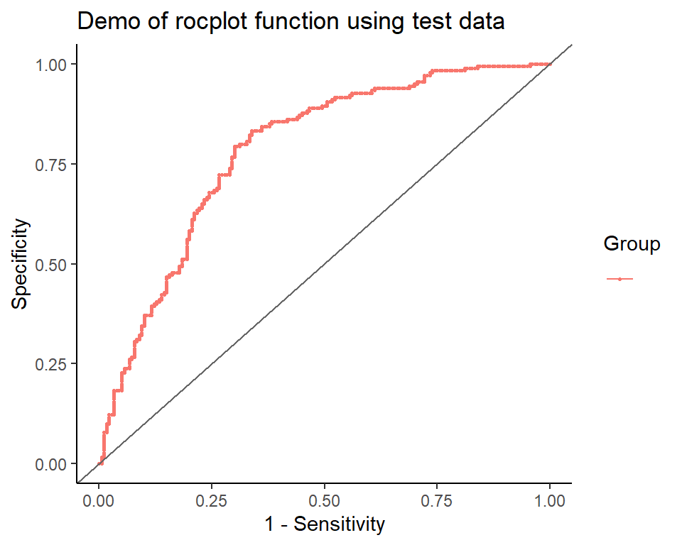

```r
rocplot(single) + labs(title = "Demo of rocplot function using test data")
```

The plot is defined using `ggplot2`, and can be manipulated after generation, e.g., by adding a theme.

Finally, the `tests` function produces a table with the statistical tests

```r
tests(single)
```

| estimate | statistic | p.value | conf.low | conf.high | method | alternative |
| --- | --- | --- | --- | --- | --- | --- |
| -4.2 | 6996 | 0 | -5 | -3.4 | Wilcoxon rank sum test with continuity correction | two.sided |

# Including a grouping variable

```r
grouped <- bouldr(dat = dd,
            f = Outcome ~ Score + Informant,
            test = 'delong',
            levels = c('no','yes'),
            direction = "<")
```

In this example, the formule contains the **grouping** variable, `Informant`, after the predictor term in the formula. A separate ROC curve will be calculated for each subset of the data specified by unique values of the grouping variable. Each curve will then be compared against each other curve using the specified statistical test.

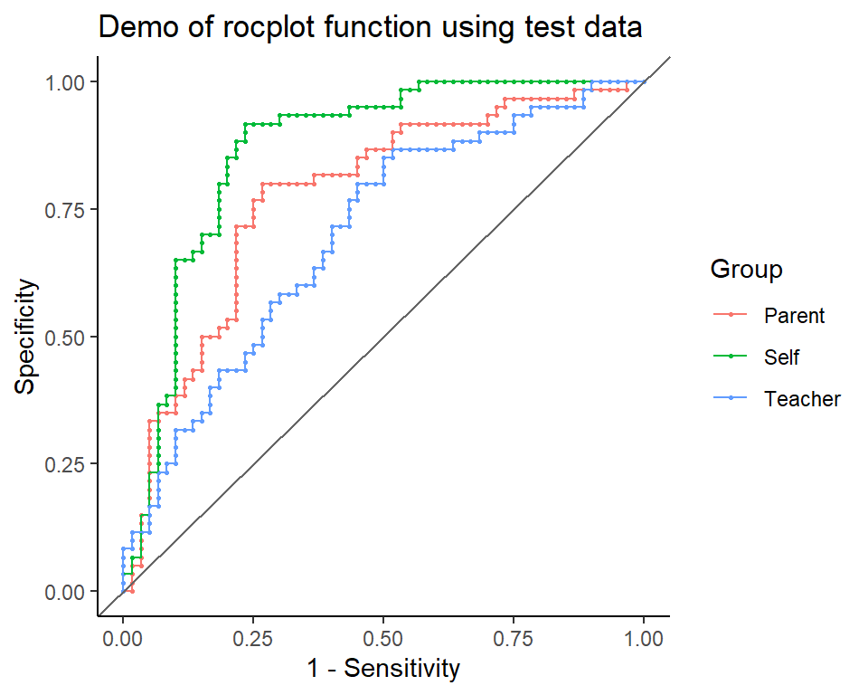

```r
rocplot(grouped) + labs(title = "Demo of rocplot function using test data")
```

The plot shows multiple ROC curves on the same axes.

```r
aucs(grouped)
```

| Group | Comparison | AUC |
| --- | --- | --- |
| Self | no < yes | 0.87 |
| Parent | no < yes | 0.78 |
| Teacher | no < yes | 0.70 |

The AUC table now includes a separate AUC for each grouping variable.

```r
tests(grouped)
```

| Informant1 | Informant2 | estimate1 | estimate2 | statistic | p.value | method | alternative |
| --- | --- | --- | --- | --- | --- | --- | --- |
| Self | Parent | 0.87 | 0.78 | 1.5 | 0.13 | DeLong’s test for two correlated ROC curves | two.sided |
| Self | Teacher | 0.87 | 0.70 | 2.8 | 0.00 | DeLong’s test for two correlated ROC curves | two.sided |
| Parent | Teacher | 0.78 | 0.70 | 1.2 | 0.24 | DeLong’s test for two correlated ROC curves | two.sided |

The tests table shows the pairwise comparisons between ROCs for each grouping variable.

# Adding a faceting variable

```r
faceted <- bouldr(dat = dd,
            f = Outcome ~ Score + Informant + Diagnosis,
            test = 'delong',
            levels = c('no','yes'),
            direction = "<")
```

Finally, we can add an additional **faceting** variable: `Diagnosis`. A variable specified after the grouping variable will create discrete sets of ROC curves that will be plotted separately. Only curves within the same faceting variable will be compared to one another using the specified statistical test; ROCs across facets are not compared. The plot below shows the effect of adding a faceting variable.

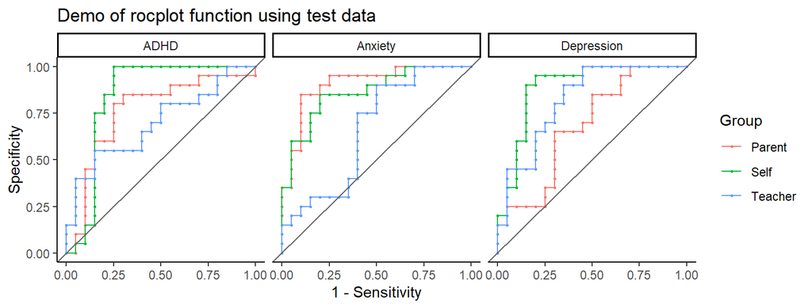

```r
rocplot(faceted) + labs(title = "Demo of rocplot function using test data")
```

Note the facet labels at the top of each plot.

```r
aucs(faceted)
```

| Facet | Group | Comparison | AUC |
| --- | --- | --- | --- |
| Depression | Self | no < yes | 0.89 |
| Depression | Parent | no < yes | 0.68 |
| Depression | Teacher | no < yes | 0.82 |
| Anxiety | Self | no < yes | 0.86 |
| Anxiety | Parent | no < yes | 0.91 |
| Anxiety | Teacher | no < yes | 0.66 |
| ADHD | Self | no < yes | 0.84 |
| ADHD | Parent | no < yes | 0.76 |
| ADHD | Teacher | no < yes | 0.70 |

The AUC table now includes a `Facet` variable, in addition to the group variable seen before.

```r
tests(faceted)
```

| Informant1 | Informant2 | Diagnosis | estimate1 | estimate2 | statistic | p.value | method | alternative |
| --- | --- | --- | --- | --- | --- | --- | --- | --- |
| Self | Parent | Depression | 0.89 | 0.68 | 1.85 | 0.06 | DeLong’s test for two correlated ROC curves | two.sided |
| Self | Teacher | Depression | 0.89 | 0.82 | 0.70 | 0.48 | DeLong’s test for two correlated ROC curves | two.sided |
| Parent | Teacher | Depression | 0.68 | 0.82 | -1.42 | 0.16 | DeLong’s test for two correlated ROC curves | two.sided |
| Self | Parent | Anxiety | 0.86 | 0.91 | -0.67 | 0.50 | DeLong’s test for two correlated ROC curves | two.sided |
| Self | Teacher | Anxiety | 0.86 | 0.66 | 2.13 | 0.03 | DeLong’s test for two correlated ROC curves | two.sided |
| Parent | Teacher | Anxiety | 0.91 | 0.66 | 2.63 | 0.01 | DeLong’s test for two correlated ROC curves | two.sided |
| Self | Parent | ADHD | 0.84 | 0.76 | 0.65 | 0.52 | DeLong’s test for two correlated ROC curves | two.sided |
| Self | Teacher | ADHD | 0.84 | 0.70 | 1.34 | 0.18 | DeLong’s test for two correlated ROC curves | two.sided |
| Parent | Teacher | ADHD | 0.76 | 0.70 | 0.53 | 0.60 | DeLong’s test for two correlated ROC curves | two.sided |

The additional variable is also included in the tests output table.

# Real data!

Here’s an example using some real data.

## Read in the data

```r
library(haven)
library(labelled)

raw.jpp.dat <- read_sav("605. ROC paper for JPP data.sav")

jpp.dat <- raw.jpp.dat %>%
  select(cgender, tint, intn_r.1, affd_r.1, anymood, crace)

colnames(jpp.dat) <- var_label(jpp.dat)

jpp.dat <- jpp.dat %>%
  mutate_at(vars(`Internalizing T Score`:`Affective Disorder Raw Score`),as.numeric) %>%
  pivot_longer(cols = `Internalizing T Score`:`Affective Disorder Raw Score`,
               names_to = "Measure", values_to = "Score") %>%
  rename("Race" = `Youth's Race/Ethnicity`, "Gender" = `Youth's Gender`) %>%
  mutate(Race = as_factor(Race),
         Gender = as_factor(Gender),
         MoodDiagnosis = as_factor(`Any Diagnosis of Mood Disorder`,levels = "values")) %>%
  select(MoodDiagnosis, Score, Measure, Gender, Race)

jpp.dat <- as.data.frame(jpp.dat)
```

## Original figure

```r
bd <- bouldr(dat = jpp.dat, f = MoodDiagnosis ~ Score + Measure,
             test = 'delong',
             levels = c(0,1),
              direction = "<")
```

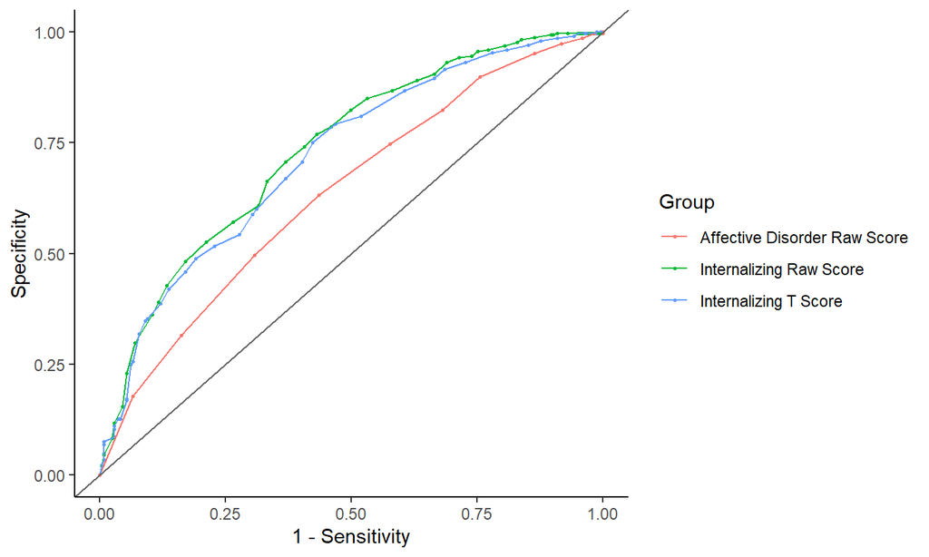

```r
rocplot(bd)
```

```r
aucs(bd)
```

| Group | Comparison | AUC |
| --- | --- | --- |
| Internalizing T Score | 0 < 1 | 0.72 |
| Internalizing Raw Score | 0 < 1 | 0.73 |
| Affective Disorder Raw Score | 0 < 1 | 0.64 |

```r
tests(bd)
```

| Measure1 | Measure2 | estimate1 | estimate2 | statistic | p.value | method | alternative |
| --- | --- | --- | --- | --- | --- | --- | --- |
| Internalizing T Score | Internalizing Raw Score | 0.72 | 0.73 | -4.3 | 0 | DeLong’s test for two correlated ROC curves | two.sided |
| Internalizing T Score | Affective Disorder Raw Score | 0.72 | 0.64 | 5.0 | 0 | DeLong’s test for two correlated ROC curves | two.sided |
| Internalizing Raw Score | Affective Disorder Raw Score | 0.73 | 0.64 | 6.0 | 0 | DeLong’s test for two correlated ROC curves | two.sided |

## Adding Race as covariate

```r
bd.race <- bouldr(dat = jpp.dat, f = MoodDiagnosis ~ Score + Measure + Race,
             test = 'delong',
             levels = c(0,1),
              direction = "<")
```

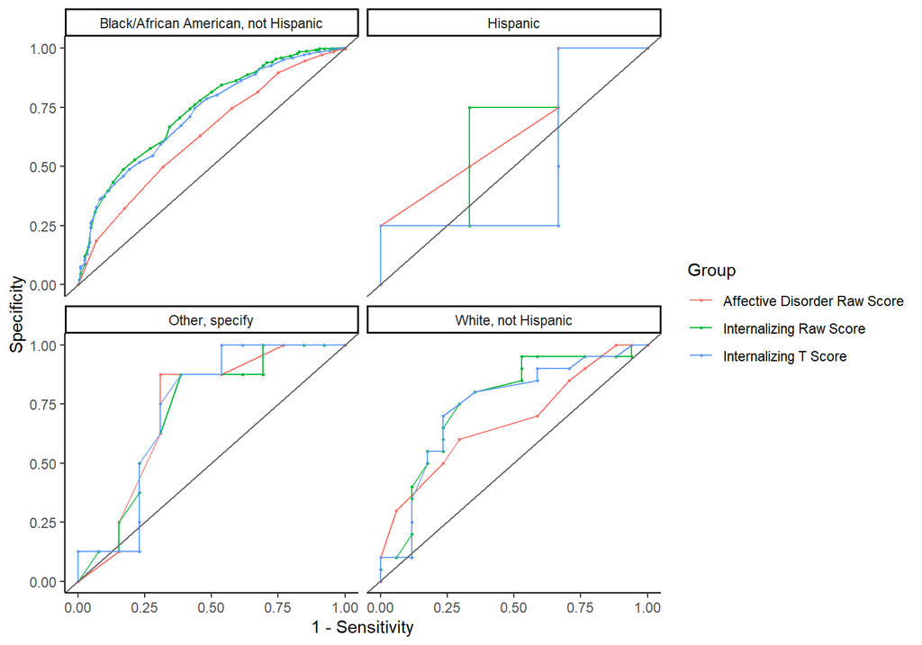

```r
rocplot(bd.race)
```

```r
aucs(bd.race)
```

| Facet | Group | Comparison | AUC |
| --- | --- | --- | --- |
| Black/African American, not Hispanic | Internalizing T Score | 0 < 1 | 0.72 |
| Black/African American, not Hispanic | Internalizing Raw Score | 0 < 1 | 0.74 |
| Black/African American, not Hispanic | Affective Disorder Raw Score | 0 < 1 | 0.63 |
| White, not Hispanic | Internalizing T Score | 0 < 1 | 0.74 |
| White, not Hispanic | Internalizing Raw Score | 0 < 1 | 0.76 |
| White, not Hispanic | Affective Disorder Raw Score | 0 < 1 | 0.68 |
| Other, specify | Internalizing T Score | 0 < 1 | 0.73 |
| Other, specify | Internalizing Raw Score | 0 < 1 | 0.72 |
| Other, specify | Affective Disorder Raw Score | 0 < 1 | 0.73 |
| Hispanic | Internalizing T Score | 0 < 1 | 0.50 |
| Hispanic | Internalizing Raw Score | 0 < 1 | 0.67 |
| Hispanic | Affective Disorder Raw Score | 0 < 1 | 0.67 |

```r
tests(bd.race)
```

| Measure1 | Measure2 | Race | estimate1 | estimate2 | statistic | p.value | method | alternative |
| --- | --- | --- | --- | --- | --- | --- | --- | --- |
| Internalizing T Score | Internalizing Raw Score | Black/African American, not Hispanic | 0.72 | 0.74 | -3.92 | 0.00 | DeLong’s test for two correlated ROC curves | two.sided |
| Internalizing T Score | Affective Disorder Raw Score | Black/African American, not Hispanic | 0.72 | 0.63 | 5.10 | 0.00 | DeLong’s test for two correlated ROC curves | two.sided |
| Internalizing Raw Score | Affective Disorder Raw Score | Black/African American, not Hispanic | 0.74 | 0.63 | 5.96 | 0.00 | DeLong’s test for two correlated ROC curves | two.sided |
| Internalizing T Score | Internalizing Raw Score | White, not Hispanic | 0.74 | 0.76 | -1.00 | 0.32 | DeLong’s test for two correlated ROC curves | two.sided |
| Internalizing T Score | Affective Disorder Raw Score | White, not Hispanic | 0.74 | 0.68 | 0.99 | 0.32 | DeLong’s test for two correlated ROC curves | two.sided |
| Internalizing Raw Score | Affective Disorder Raw Score | White, not Hispanic | 0.76 | 0.68 | 1.25 | 0.21 | DeLong’s test for two correlated ROC curves | two.sided |
| Internalizing T Score | Internalizing Raw Score | Other, specify | 0.73 | 0.72 | 0.45 | 0.65 | DeLong’s test for two correlated ROC curves | two.sided |
| Internalizing T Score | Affective Disorder Raw Score | Other, specify | 0.73 | 0.73 | 0.04 | 0.97 | DeLong’s test for two correlated ROC curves | two.sided |
| Internalizing Raw Score | Affective Disorder Raw Score | Other, specify | 0.72 | 0.73 | -0.09 | 0.93 | DeLong’s test for two correlated ROC curves | two.sided |
| Internalizing T Score | Internalizing Raw Score | Hispanic | 0.50 | 0.67 | -0.87 | 0.39 | DeLong’s test for two correlated ROC curves | two.sided |
| Internalizing T Score | Affective Disorder Raw Score | Hispanic | 0.50 | 0.67 | -1.03 | 0.30 | DeLong’s test for two correlated ROC curves | two.sided |
| Internalizing Raw Score | Affective Disorder Raw Score | Hispanic | 0.67 | 0.67 | 0.00 | 1.00 | DeLong’s test for two correlated ROC curves | two.sided |

# Future directions

- format as a real R package?
- add more documentation
- error checking & red-teaming
- add print and summary functions to bouldr object
- allow additional arguments to be passed to roc and roc.test
- add option for smoothed curves